# Wood_G_HW_Classsification

"On my honor, as a student, I have neither given nor received unauthorized aid on this academic work."¶

```python
from IPython.display import Image
from IPython.core.display import HTML
Image(url= "https://media1.tenor.com/images/19042a1d74a71a7694c0b9914e3aa29e/tenor.gif?itemid=8557097")
```

[figure not shown]

```python
import numpy as np
import pandas as pd
import matplotlib.pyplot as plt
import seaborn as sns
%matplotlib inline

#import decisiontreeclassifier
from sklearn import tree
from sklearn.tree import DecisionTreeClassifier
#import logisticregression classifier
from sklearn.linear_model import LogisticRegression
import statsmodels.api as sm
#import knn classifier
from sklearn.neighbors import KNeighborsClassifier

#for validating your classification model
from sklearn.model_selection import train_test_split
from sklearn.model_selection import cross_val_score
from sklearn import metrics
from sklearn.metrics import roc_curve, auc

# feature selection
from sklearn.feature_selection import RFE
from sklearn.ensemble import ExtraTreesClassifier
from sklearn.feature_selection import SelectKBest
from sklearn.feature_selection import chi2
```

# 1) Business Understanding: The question (and step) is that you review the problem statement and the description about the columns (or variables) in the dataset, and develop three hypotheses, which you can test using statistics (e.g., t-testing) and classification analysis on the dataset. Provide the rationale for the hypotheses.

## A) The higher the average hours worked per month the higher the chance the employee will quit.

#### Rational: Overworked employees are more likely to get burned out and leave

### B) The low the employee satisfaction level the higher the chance that the employee will leave

#### Rational: Unhappy employees are more likely to quitt

### C) The lower the salary the more likely an employee is to quit

#### Rational: Underpaid employees are less loyal to their job

# 2) Demonstrate your data cleaning & transformation skills. Any data quality issues? Check any missing value. What did you handle missing values and other data quality issues? What features (or variables) need to be transformed (e.g., categorical variables?, encoding categorical variables, changing data types)?

```python
df=pd.read_csv("data/turnover.csv")
print df.head()
```

```
   satisfaction_level  last_evaluation  number_project  average_montly_hours  \
0                0.38             0.53               2                   157
1                0.80             0.86               5                   262
2                0.11             0.88               7                   272
3                0.72             0.87               5                   223
4                0.37             0.52               2                   159

   time_spend_company  Work_accident  left  promotion_last_5years  sales  \
0                   3              0     1                      0  sales
1                   6              0     1                      0  sales
2                   4              0     1                      0  sales
3                   5              0     1                      0  sales
4                   3              0     1                      0  sales

   salary
0     low
1  medium
2  medium
3     low
4     low
```

```python
df.info()
```

```
<class 'pandas.core.frame.DataFrame'>
RangeIndex: 14999 entries, 0 to 14998
Data columns (total 10 columns):
satisfaction_level       14999 non-null float64
last_evaluation          14999 non-null float64
number_project           14999 non-null int64
average_montly_hours     14999 non-null int64
time_spend_company       14999 non-null int64
Work_accident            14999 non-null int64
left                     14999 non-null int64
promotion_last_5years    14999 non-null int64
sales                    14999 non-null object
salary                   14999 non-null object
dtypes: float64(2), int64(6), object(2)
memory usage: 1.1+ MB
```

```python
df.describe()
```

|  | satisfaction_level | last_evaluation | number_project | average_montly_hours | time_spend_company | Work_accident | left | promotion_last_5years |
| --- | --- | --- | --- | --- | --- | --- | --- | --- |
| count | 14999.000000 | 14999.000000 | 14999.000000 | 14999.000000 | 14999.000000 | 14999.000000 | 14999.000000 | 14999.000000 |
| mean | 0.612834 | 0.716102 | 3.803054 | 201.050337 | 3.498233 | 0.144610 | 0.238083 | 0.021268 |
| std | 0.248631 | 0.171169 | 1.232592 | 49.943099 | 1.460136 | 0.351719 | 0.425924 | 0.144281 |
| min | 0.090000 | 0.360000 | 2.000000 | 96.000000 | 2.000000 | 0.000000 | 0.000000 | 0.000000 |
| 25% | 0.440000 | 0.560000 | 3.000000 | 156.000000 | 3.000000 | 0.000000 | 0.000000 | 0.000000 |
| 50% | 0.640000 | 0.720000 | 4.000000 | 200.000000 | 3.000000 | 0.000000 | 0.000000 | 0.000000 |
| 75% | 0.820000 | 0.870000 | 5.000000 | 245.000000 | 4.000000 | 0.000000 | 0.000000 | 0.000000 |
| max | 1.000000 | 1.000000 | 7.000000 | 310.000000 | 10.000000 | 1.000000 | 1.000000 | 1.000000 |

```python
df.isnull().sum()
```

```
satisfaction_level       0
last_evaluation          0
number_project           0
average_montly_hours     0
time_spend_company       0
Work_accident            0
left                     0
promotion_last_5years    0
sales                    0
salary                   0
dtype: int64
```

```python
df.columns
```

```
Index([u'satisfaction_level', u'last_evaluation', u'number_project',
       u'average_montly_hours', u'time_spend_company', u'Work_accident',
       u'left', u'promotion_last_5years', u'sales', u'salary'],
      dtype='object')
```

```python
#mappling or replacing
df = df.replace({'salary': 'low'}, {'salary': 1})
df = df.replace({'salary': 'medium'}, {'salary': 2})
df = df.replace({'salary': 'high'}, {'salary': 3})
```

```python
df.groupby('sales').nunique()
```

| sales | satisfaction_level | last_evaluation | number_project | average_montly_hours | time_spend_company | Work_accident | left | promotion_last_5years | sales | salary |
| --- | --- | --- | --- | --- | --- | --- | --- | --- | --- | --- |
| IT | 90 | 64 | 6 | 195 | 8 | 2 | 2 | 2 | 1 | 3 |
| RandD | 90 | 65 | 6 | 175 | 6 | 2 | 2 | 2 | 1 | 3 |
| accounting | 90 | 64 | 6 | 178 | 7 | 2 | 2 | 2 | 1 | 3 |
| hr | 90 | 63 | 6 | 176 | 6 | 2 | 2 | 2 | 1 | 3 |
| management | 86 | 62 | 6 | 163 | 8 | 2 | 2 | 2 | 1 | 3 |
| marketing | 90 | 64 | 6 | 181 | 8 | 2 | 2 | 2 | 1 | 3 |
| product_mng | 88 | 65 | 6 | 182 | 8 | 2 | 2 | 1 | 1 | 3 |
| sales | 92 | 65 | 6 | 214 | 8 | 2 | 2 | 2 | 1 | 3 |
| support | 92 | 65 | 6 | 204 | 7 | 2 | 2 | 2 | 1 | 3 |
| technical | 92 | 65 | 6 | 209 | 8 | 2 | 2 | 2 | 1 | 3 |

```python
## I originally did sales dummies but once I realized they showed no correlation I decided to just drop the column all together
##sales_dummies = pd.get_dummies(df['sales'], prefix = 'division_')
##df = df.join(sales_dummies)
promotion_dummies = pd.get_dummies(df['promotion_last_5years'], prefix = 'promotion_')
df = df.join(promotion_dummies)
```

```python
df['salary'] = df['salary'].astype(int)
print df.dtypes
```

```
satisfaction_level       float64
last_evaluation          float64
number_project             int64
average_montly_hours       int64
time_spend_company         int64
Work_accident              int64
left                       int64
promotion_last_5years      int64
sales                     object
salary                     int32
promotion__0               uint8
promotion__1               uint8
dtype: object
```

```python
df.describe()
```

|  | satisfaction_level | last_evaluation | number_project | average_montly_hours | time_spend_company | Work_accident | left | promotion_last_5years | salary | promotion__0 | promotion__1 |
| --- | --- | --- | --- | --- | --- | --- | --- | --- | --- | --- | --- |
| count | 14999.000000 | 14999.000000 | 14999.000000 | 14999.000000 | 14999.000000 | 14999.000000 | 14999.000000 | 14999.000000 | 14999.000000 | 14999.000000 | 14999.000000 |
| mean | 0.612834 | 0.716102 | 3.803054 | 201.050337 | 3.498233 | 0.144610 | 0.238083 | 0.021268 | 1.594706 | 0.978732 | 0.021268 |
| std | 0.248631 | 0.171169 | 1.232592 | 49.943099 | 1.460136 | 0.351719 | 0.425924 | 0.144281 | 0.637183 | 0.144281 | 0.144281 |
| min | 0.090000 | 0.360000 | 2.000000 | 96.000000 | 2.000000 | 0.000000 | 0.000000 | 0.000000 | 1.000000 | 0.000000 | 0.000000 |
| 25% | 0.440000 | 0.560000 | 3.000000 | 156.000000 | 3.000000 | 0.000000 | 0.000000 | 0.000000 | 1.000000 | 1.000000 | 0.000000 |
| 50% | 0.640000 | 0.720000 | 4.000000 | 200.000000 | 3.000000 | 0.000000 | 0.000000 | 0.000000 | 2.000000 | 1.000000 | 0.000000 |
| 75% | 0.820000 | 0.870000 | 5.000000 | 245.000000 | 4.000000 | 0.000000 | 0.000000 | 0.000000 | 2.000000 | 1.000000 | 0.000000 |
| max | 1.000000 | 1.000000 | 7.000000 | 310.000000 | 10.000000 | 1.000000 | 1.000000 | 1.000000 | 3.000000 | 1.000000 | 1.000000 |

# 3) Demonstrate your data visualization skills (e.g., charts, pivot tables). You should explore matplot and seaborn (interactive plots are optional). The focus should be on identifying X variables (independent variables) affecting Y value (dependent variable, “left” in the dataset). What X variables appear to influence on “whether the employee left the workplace or not (1 or 0)”?

```
left
0    AxesSubplot(0.125,0.125;0.775x0.755)
1    AxesSubplot(0.125,0.125;0.775x0.755)
Name: salary, dtype: object
```

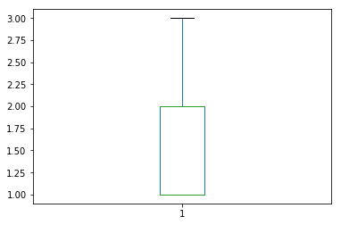

```python
df.groupby('left').salary.plot(kind = 'box')
```

### based on the boxplot, those who quit primaryly had lower salaries

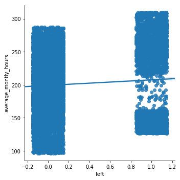

```python
sns.lmplot("left", "average_montly_hours", df, x_jitter=.15)
```

## The more houurs someone works the more likely they'll leave. There does not appear to be a very strong correlation here but we will explore more later

```
left
0    [[AxesSubplot(0.125,0.125;0.775x0.755)]]
1    [[AxesSubplot(0.125,0.125;0.775x0.755)]]
dtype: object
```

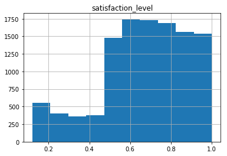

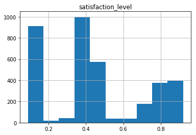

```python
df.groupby('left').hist('satisfaction_level')
```

```
left
0    AxesSubplot(0.125,0.125;0.775x0.755)
1    AxesSubplot(0.125,0.125;0.775x0.755)
Name: satisfaction_level, dtype: object
```

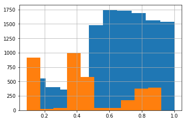

```python
df.groupby('left').satisfaction_level.hist(alpha=0.9)
```

### Based on the histograms it appears that those with lower levels of job satisfaction appear more likely to quit

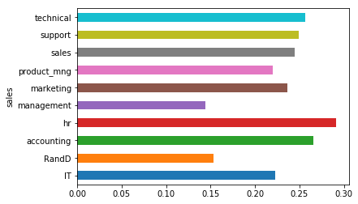

```python
df.groupby(['sales']).left.mean().plot(kind='barh')
```

### HR, accounting, technical, support, sales have higher quit ratios

```
left
0    AxesSubplot(0.125,0.125;0.775x0.755)
1    AxesSubplot(0.125,0.125;0.775x0.755)
Name: salary, dtype: object
```

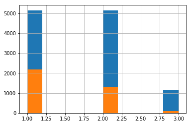

```python
df.groupby('left').salary.hist(alpha=0.9)
```

## The lesss someone is paid the more likely they are to quit

# 4) Demonstrate your exploratory data analysis (EDA) and statistical hypothesis testing skills (e.g., correlation analysis, heatmap, hypothesis testing). What X variables appear to influence on “whether the employee left the workplace or not (1 or 0)”? What X variables are highly correlated to each other? The dataset contains two groups of employees (those left from and those remaining with their organizations). Earlier, you developed three hypotheses. Perform hypothesis testing here.

```python
df = df.drop('sales', axis = 1 )
df = df.drop('promotion_last_5years', axis = 1 )
```

```python
df.corr()
```

|  | satisfaction_level | last_evaluation | number_project | average_montly_hours | time_spend_company | Work_accident | left | salary | promotion__0 | promotion__1 |
| --- | --- | --- | --- | --- | --- | --- | --- | --- | --- | --- |
| satisfaction_level | 1.000000 | 0.105021 | -0.142970 | -0.020048 | -0.100866 | 0.058697 | -0.388375 | 0.050022 | -0.025605 | 0.025605 |
| last_evaluation | 0.105021 | 1.000000 | 0.349333 | 0.339742 | 0.131591 | -0.007104 | 0.006567 | -0.013002 | 0.008684 | -0.008684 |
| number_project | -0.142970 | 0.349333 | 1.000000 | 0.417211 | 0.196786 | -0.004741 | 0.023787 | -0.001803 | 0.006064 | -0.006064 |
| average_montly_hours | -0.020048 | 0.339742 | 0.417211 | 1.000000 | 0.127755 | -0.010143 | 0.071287 | -0.002242 | 0.003544 | -0.003544 |
| time_spend_company | -0.100866 | 0.131591 | 0.196786 | 0.127755 | 1.000000 | 0.002120 | 0.144822 | 0.048715 | -0.067433 | 0.067433 |
| Work_accident | 0.058697 | -0.007104 | -0.004741 | -0.010143 | 0.002120 | 1.000000 | -0.154622 | 0.009247 | -0.039245 | 0.039245 |
| left | -0.388375 | 0.006567 | 0.023787 | 0.071287 | 0.144822 | -0.154622 | 1.000000 | -0.157898 | 0.061788 | -0.061788 |
| salary | 0.050022 | -0.013002 | -0.001803 | -0.002242 | 0.048715 | 0.009247 | -0.157898 | 1.000000 | -0.098119 | 0.098119 |
| promotion__0 | -0.025605 | 0.008684 | 0.006064 | 0.003544 | -0.067433 | -0.039245 | 0.061788 | -0.098119 | 1.000000 | -1.000000 |
| promotion__1 | 0.025605 | -0.008684 | -0.006064 | -0.003544 | 0.067433 | 0.039245 | -0.061788 | 0.098119 | -1.000000 | 1.000000 |

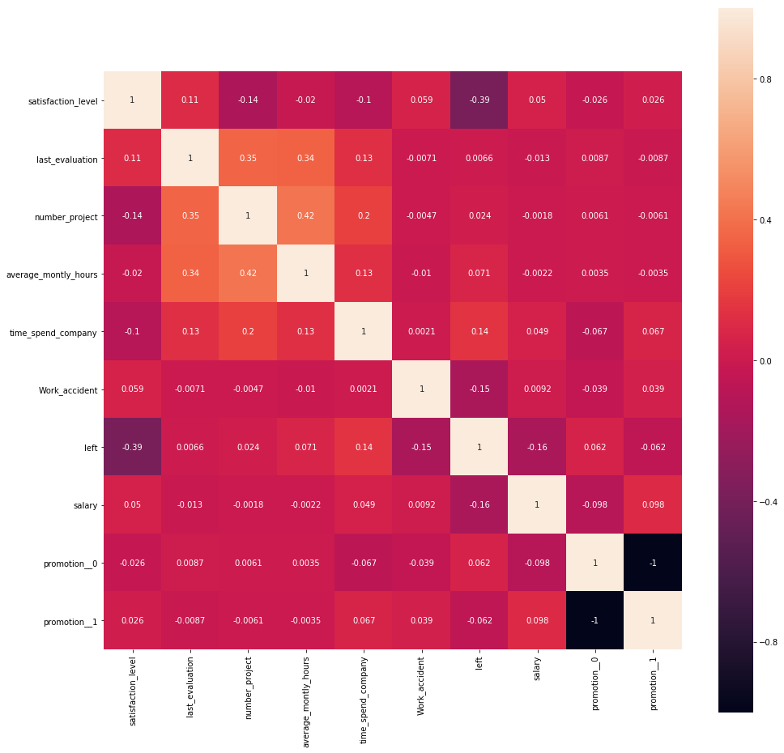

```python
plt.figure(figsize=(16, 16))

sns.heatmap(df.corr(), square= True, annot = True)
```

## Satisfaction has a strong negative correlation with leaving

## time spent at company has a correlation to leaving

## Salary has a negative correlation to leaving

# 5) Demonstrate your skills in building, validating and evaluating classification models. You need to use the following machine learning algorithms and report the model performance: a) Decision tree b) Knn c) Logistic regression d) Random Forest Classifier

# A) Decision Tree

```python
y = df['left']
X = df.drop(['left',], axis=1)
```

```python
# split validation
X_train, X_test, y_train, y_test = train_test_split(X, y, test_size=0.3, random_state=0)

# Initialize DecisionTreeClassifier()
dt = DecisionTreeClassifier()

# Train a decision tree model
dt.fit(X_train, y_train)
```

```
DecisionTreeClassifier(class_weight=None, criterion='gini', max_depth=None,
            max_features=None, max_leaf_nodes=None,
            min_impurity_decrease=0.0, min_impurity_split=None,
            min_samples_leaf=1, min_samples_split=2,
            min_weight_fraction_leaf=0.0, presort=False, random_state=None,
            splitter='best')
```

```python
print metrics.accuracy_score(y_test, dt.predict(X_test))
print "--------------------------------------------------------"
print metrics.confusion_matrix(y_test, dt.predict(X_test))
print "--------------------------------------------------------"
print metrics.classification_report(y_test, dt.predict(X_test))
print "--------------------------------------------------------"
print metrics.roc_auc_score(y_test, dt.predict(X_test))
```

```
0.9786666666666667
--------------------------------------------------------
[[3396   66]
 [  30 1008]]
--------------------------------------------------------
             precision    recall  f1-score   support

          0       0.99      0.98      0.99      3462
          1       0.94      0.97      0.95      1038

avg / total       0.98      0.98      0.98      4500

--------------------------------------------------------
0.9760170705562958
```

```python
tree.export_graphviz(dt, out_file='data/decisiontree.dot', feature_names=X.columns)
```

```python
from IPython.display import Image
Image("data/decisiontree.png")
```

[figure not shown]

```python
#too complicated
```

```python
dt = DecisionTreeClassifier()    # develop a very complex ("full-grown") tree

# You can make a simpler decision tree

X_train, X_test, y_train, y_test = train_test_split(X, y, test_size=0.3, random_state=0)
dt_simple = DecisionTreeClassifier(max_depth=3, min_samples_leaf=5)
dt_simple.fit(X_train, y_train)
X_train, X_test, y_train, y_test = train_test_split(X, y, test_size=0.3, random_state=0)

print metrics.accuracy_score(y_test, dt_simple.predict(X_test))
print "--------------------------------------------------------"
print metrics.confusion_matrix(y_test, dt_simple.predict(X_test))
print "--------------------------------------------------------"
print metrics.classification_report(y_test, dt_simple.predict(X_test))
print "--------------------------------------------------------"
print metrics.roc_auc_score(y_test, dt_simple.predict(X_test))
```

```
0.9533333333333334
--------------------------------------------------------
[[3332  130]
 [  80  958]]
--------------------------------------------------------
             precision    recall  f1-score   support

          0       0.98      0.96      0.97      3462
          1       0.88      0.92      0.90      1038

avg / total       0.95      0.95      0.95      4500

--------------------------------------------------------
0.9426890801200816
```

```python
tree.export_graphviz(dt_simple, out_file='data/decisiontree_simple.dot', feature_names=X.columns)
```

[figure not shown]

```python
from IPython.display import Image
Image("data/decisiontree_simple.png")
```

```python
score=pd.read_csv("data/heartattack_scoring.csv")
score.head(2)
```

|  | Age | Marital_Status | Gender | Weight_Category | Cholesterol | Stress_Management | Trait_Anxiety |
| --- | --- | --- | --- | --- | --- | --- | --- |
| 0 | 61 | 0 | 1 | 1 | 139 | 1 | 50 |
| 1 | 55 | 2 | 1 | 2 | 163 | 0 | 40 |

# b) Random Forest

```python
from sklearn.ensemble import RandomForestClassifier

clf = RandomForestClassifier(n_estimators=20)    #building 20 decision trees
clf=clf.fit(X_train, y_train)
clf.score(X_test, y_test)
```

```
0.9904444444444445
```

```python
print metrics.accuracy_score(y_test, clf.predict(X_test)) #overall accuracy
print metrics.confusion_matrix(y_test, clf.predict(X_test))
print metrics.classification_report(y_test, clf.predict(X_test))
```

```
0.9904444444444445
[[3450   12]
 [  31 1007]]
             precision    recall  f1-score   support

          0       0.99      1.00      0.99      3462
          1       0.99      0.97      0.98      1038

avg / total       0.99      0.99      0.99      4500
```

```python
pd.DataFrame({'feature':X.columns, 'importance':clf.feature_importances_}).\
                                                    sort_values('importance',ascending=False)
```

|  | feature | importance |
| --- | --- | --- |
| 0 | satisfaction_level | 0.357167 |
| 4 | time_spend_company | 0.183907 |
| 2 | number_project | 0.162938 |
| 3 | average_montly_hours | 0.152542 |
| 1 | last_evaluation | 0.126796 |
| 6 | salary | 0.009716 |
| 5 | Work_accident | 0.006081 |
| 7 | promotion__0 | 0.000450 |
| 8 | promotion__1 | 0.000403 |

```python
clf.predict_proba(X_test)
```

```
array([[0.  , 1.  ],
       [1.  , 0.  ],
       [1.  , 0.  ],
       ...,
       [1.  , 0.  ],
       [0.8 , 0.2 ],
       [0.95, 0.05]])
```

# C) KNN

```python
knn = KNeighborsClassifier()

knn.fit(X_train, y_train)
```

```
KNeighborsClassifier(algorithm='auto', leaf_size=30, metric='minkowski',
           metric_params=None, n_jobs=1, n_neighbors=5, p=2,
           weights='uniform')
```

```python
print metrics.accuracy_score(y_test, knn.predict(X_test))
print "--------------------------------------------------------"
print metrics.confusion_matrix(y_test, knn.predict(X_test))
print "--------------------------------------------------------"
print metrics.classification_report(y_test, knn.predict(X_test))
print "--------------------------------------------------------"
print metrics.roc_auc_score(y_test, knn.predict(X_test))
```

```
0.946
--------------------------------------------------------
[[3301  161]
 [  82  956]]
--------------------------------------------------------
             precision    recall  f1-score   support

          0       0.98      0.95      0.96      3462
          1       0.86      0.92      0.89      1038

avg / total       0.95      0.95      0.95      4500

--------------------------------------------------------
0.9372485081629449
```

```python
scores = cross_val_score(knn, X, y, scoring='accuracy', cv=10)
print scores
print scores.mean()
```

```
[0.94536975 0.944      0.94       0.93933333 0.93933333 0.93733333
 0.95333333 0.94333333 0.96264176 0.95730487]
0.9461983051251727
```

```
Text(0,0.5,u'accuracy')
```

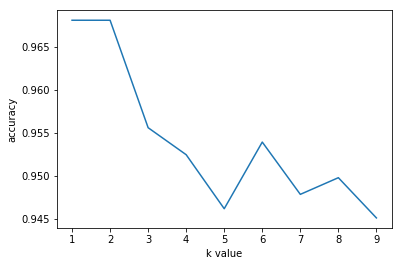

```python
k_range = range(1, 10)
scores = []
for k in k_range:
    knn = KNeighborsClassifier(n_neighbors=k)
    scores.append(np.mean(cross_val_score(knn, X, y, cv=10, scoring='accuracy')))

# plot the K values (x-axis) versus the 10-fold CV score (y-axis)
plt.figure()
plt.plot(k_range, scores)
plt.xlabel('k value')
plt.ylabel('accuracy')
```

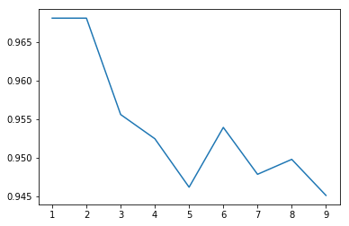

```python
from sklearn.grid_search import GridSearchCV

knn = KNeighborsClassifier()
k_range = range(1, 10)
param_grid = dict(n_neighbors=k_range)
grid = GridSearchCV(knn, param_grid, cv=10, scoring='accuracy')
grid.fit(X, y)

# check the results of the grid search
grid.grid_scores_
grid_mean_scores = [result[1] for result in grid.grid_scores_]
plt.figure()
plt.plot(k_range, grid_mean_scores)
plt.show()
```

```python
print grid.best_score_
print grid.best_params_
print grid.best_estimator_
```

```
0.968064537636
{'n_neighbors': 1}
KNeighborsClassifier(algorithm='auto', leaf_size=30, metric='minkowski',
           metric_params=None, n_jobs=1, n_neighbors=1, p=2,
           weights='uniform')
```

```python
X_train, X_test, y_train, y_test = train_test_split(X, y, test_size=0.3, random_state=0)
knn = KNeighborsClassifier(n_neighbors=3)
knn.fit(X_train, y_train)
```

```
KNeighborsClassifier(algorithm='auto', leaf_size=30, metric='minkowski',
           metric_params=None, n_jobs=1, n_neighbors=3, p=2,
           weights='uniform')
```

```python
print metrics.accuracy_score(y_test, knn.predict(X_test))
print metrics.confusion_matrix(y_test, knn.predict(X_test))
print metrics.classification_report(y_test, knn.predict(X_test))
print metrics.roc_auc_score(y_test, knn.predict(X_test))
```

```
0.9495555555555556
[[3302  160]
 [  67  971]]
             precision    recall  f1-score   support

          0       0.98      0.95      0.97      3462
          1       0.86      0.94      0.90      1038

avg / total       0.95      0.95      0.95      4500

0.9446183668767093
```

# D) Logistical Regression

```python
lr = LogisticRegression()

lr.fit(X_train, y_train)
```

```
LogisticRegression(C=1.0, class_weight=None, dual=False, fit_intercept=True,
          intercept_scaling=1, max_iter=100, multi_class='ovr', n_jobs=1,
          penalty='l2', random_state=None, solver='liblinear', tol=0.0001,
          verbose=0, warm_start=False)
```

```python
print metrics.accuracy_score(y_test, lr.predict(X_test))
print "--------------------------------------------------------"
print metrics.confusion_matrix(y_test, lr.predict(X_test))
print "--------------------------------------------------------"
print metrics.classification_report(y_test, lr.predict(X_test))
print "--------------------------------------------------------"
print metrics.roc_auc_score(y_test, lr.predict(X_test))
```

```
0.7937777777777778
--------------------------------------------------------
[[3199  263]
 [ 665  373]]
--------------------------------------------------------
             precision    recall  f1-score   support

          0       0.83      0.92      0.87      3462
          1       0.59      0.36      0.45      1038

avg / total       0.77      0.79      0.77      4500

--------------------------------------------------------
0.6416886226345158
```

```python
# not very accurate for this data set
```

# 6) Demonstrate your understanding of feature selection in classification analysis. Now, you need to build classification models using feature selection. The goal is to find the best classification model with the highest accuracy and interpretability. According to different feature selection techniques, what variables are considered important in predicting employee turnover?

```python
X_new = SelectKBest(chi2, k=3).fit_transform(X, y)
print X_new
```

```
[[3.80e-01 1.57e+02 0.00e+00]
 [8.00e-01 2.62e+02 0.00e+00]
 [1.10e-01 2.72e+02 0.00e+00]
 ...
 [3.70e-01 1.43e+02 0.00e+00]
 [1.10e-01 2.80e+02 0.00e+00]
 [3.70e-01 1.58e+02 0.00e+00]]
```

```python
selector = SelectKBest(chi2, k=4).fit(X, y)
idxs_selected = selector.get_support(indices=True)
print idxs_selected
```

```
[0 3 4 5]
```

```python
X.head(1)
```

|  | satisfaction_level | last_evaluation | number_project | average_montly_hours | time_spend_company | Work_accident | salary | promotion__0 | promotion__1 |
| --- | --- | --- | --- | --- | --- | --- | --- | --- | --- |
| 0 | 0.38 | 0.53 | 2 | 157 | 3 | 0 | 1 | 1 | 0 |

- 0 --> 1th column
- 3 --> 4th column
- 5 --> 6th column

**satisfaction_level, average_monthly_hours, and work_accident** are selected as three best predictors

```python
# evaluate the model by splitting into train (70%) and test sets (30%)
X_train, X_test, y_train, y_test = train_test_split(X_new, y, test_size=0.3, random_state=0)
#model2 = tree.DecisionTreeClassifier(criterion='entropy', max_depth=3,min_samples_leaf=5)
dt = tree.DecisionTreeClassifier()
dt.fit(X_train, y_train)

#Model evaluation
print metrics.accuracy_score(y_test, dt.predict(X_test))
print "--------------------------------------------------------"
print metrics.confusion_matrix(y_test, dt.predict(X_test))
print "--------------------------------------------------------"
print metrics.classification_report(y_test, dt.predict(X_test))
print "--------------------------------------------------------"
print metrics.roc_auc_score(y_test, dt.predict(X_test))
```

```
0.9204444444444444
--------------------------------------------------------
[[3282  180]
 [ 178  860]]
--------------------------------------------------------
             precision    recall  f1-score   support

          0       0.95      0.95      0.95      3462
          1       0.83      0.83      0.83      1038

avg / total       0.92      0.92      0.92      4500

--------------------------------------------------------
0.8882616550291689
```

```python
# develop logistic regression model with X_new (only three predictors or independent variables)

X_train, X_test, y_train, y_test = train_test_split(X_new, y, test_size=0.3, random_state=0)
clf = RandomForestClassifier(n_estimators=20)    #building 20 decision trees
clf=clf.fit(X_train, y_train)
clf.score(X_test, y_test)

#Model evaluation
print metrics.accuracy_score(y_test, clf.predict(X_test))
print metrics.confusion_matrix(y_test, clf.predict(X_test))
print metrics.classification_report(y_test, clf.predict(X_test))
print metrics.roc_auc_score(y_test, clf.predict(X_test))
```

```
0.9326666666666666
[[3306  156]
 [ 147  891]]
             precision    recall  f1-score   support

          0       0.96      0.95      0.96      3462
          1       0.85      0.86      0.85      1038

avg / total       0.93      0.93      0.93      4500

0.9066604221556588
```

# RFE

```python
model = LogisticRegression()
rfe = RFE(model, 4)  #asking four best attributes
rfe = rfe.fit(X, y)
# summarize the selection of the attributes
print(rfe.support_)
print(rfe.ranking_)
```

```
[ True False False False False  True  True  True False]
[1 4 5 6 3 1 1 1 2]
```

```python
pd.DataFrame({'feature':X.columns, 'importance':rfe.ranking_})
```

|  | feature | importance |
| --- | --- | --- |
| 0 | satisfaction_level | 1 |
| 1 | last_evaluation | 4 |
| 2 | number_project | 5 |
| 3 | average_montly_hours | 6 |
| 4 | time_spend_company | 3 |
| 5 | Work_accident | 1 |
| 6 | salary | 1 |
| 7 | promotion__0 | 1 |
| 8 | promotion__1 | 2 |

```python
X_logistic = df[['satisfaction_level', 'average_montly_hours', 'time_spend_company', 'Work_accident']]
print X_logistic.head()
```

```
   satisfaction_level  average_montly_hours  time_spend_company  Work_accident
0                0.38                   157                   3              0
1                0.80                   262                   6              0
2                0.11                   272                   4              0
3                0.72                   223                   5              0
4                0.37                   159                   3              0
```

```python
X_train, X_test, y_train, y_test = train_test_split(X_logistic, y, test_size=0.3, random_state=0)
clf = RandomForestClassifier(n_estimators=20)    #building 20 decision trees
clf=clf.fit(X_train, y_train)
clf.score(X_test, y_test)

#Model evaluation
print metrics.accuracy_score(y_test, clf.predict(X_test))
print metrics.confusion_matrix(y_test, clf.predict(X_test))
print metrics.classification_report(y_test, clf.predict(X_test))
print metrics.roc_auc_score(y_test, clf.predict(X_test))
```

```
0.9795555555555555
[[3416   46]
 [  46  992]]
             precision    recall  f1-score   support

          0       0.99      0.99      0.99      3462
          1       0.96      0.96      0.96      1038

avg / total       0.98      0.98      0.98      4500

0.9711984452169383
```